# algorithms_helpers

### Processing Steps

1. **Input Handling**: Each input stream is received by the “route” audio processing block.
2. **Channel Selection & format conversion**:
- For each input, the user specifies which channels to route to the output.
- The block extracts the selected channels from each input stream using an internal algorithm called SFC (Samples Format Converter). This algorithm supports various input formats and is able to deliver different ones on the output.
- Route supports following format conversion:
  1. interleaved into non interleaved samples and vice versa.
  2. Can convert from any of this data type to any other within this list: FIXED16, FIXED32, FLOAT, G711.
  3. Can convert input PDM LSB into PDM MSB and vice versa.
- Route doesn’t support the following format conversion:
  1. It cannot convert PCM to PDM data nor PDM into PCM data (see PDM2PCM algorithm for that).
  2. It cannot convert sampling frequency.
1. **Output Generation**:
- composite stream is then delivered as the final product of the audio processing block.

### Configuration Parameters

By default, the configuration is empty as depicted by following figure.

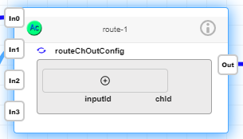

Click the “+” button to add output channels and select your input pin thanks to “inputId” and its channel thanks to “chId” (see following figure).

Up to 8 output channels can be configured (8 clicks on the “+” button), output chunk must have at least this number of configured output channels, if it has more channels, the last unconfigured channels are muted.

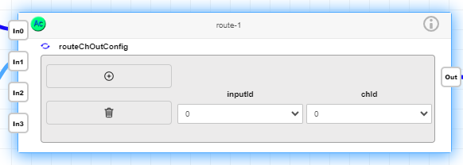

### Usage Example and Hints

Input streams can be connected to any input pins, i.e. pin1 can be used even if pin0 is not connected.

## Sam

Stands for Speech Automatic Magnifier

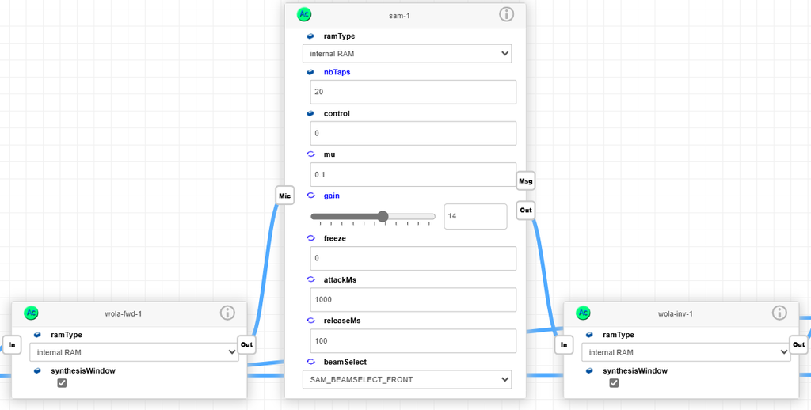

.

### Overview

This document describes an audio front end which aims at boosting voice recognition performances in a noisy environment. The processing is done in the frequency domain.

### Features

- Adaptive filtering for interference signal removal
- Tracking of interference location
- Dynamic mixing of processed & input signals as function of ambiant noise

### Inputs/Outputs

- **Input Stream**: Two microphones data streams in the frequency domain.
- **Parameters**: See the chapter called **Configuration Parameters**.

#### Output

- **Output Stream**: Microphone signal with reduced interferences. Signal still the in the frequency domain (mono).

### Configuration Parameters

There are three types of parameters:

1. Input & output streams configuration:
- Since it is in the frequency domain, there are some constraints to respect. These constraints are detailed inside both WolaFwd & WolaInv algorithms in the chapter called Frequency domain constraints in AudioChain/LiveTune
- This specific algorithm is hard coded for input streams of 129 bands. The WOLA algorithms must be tuned accordingly.
2. Static parameters:
- nbTaps:
  - It is the number of taps of the adaptive filtering.
- control:
  - It allows to activate the control API
    - if 0 control is not active
    - if n, the control callback registered thru `AudioAlgo_setCtrlCb` will be call every N*frame_size
3. Dynamic parameters:
- freeze:
  - freeze the interference location
- beamSelect:
  - In case interfence location is not wanted, this parameter allows to chose the direction to the user; aka which microphone is the front one.
  - In other words, it allows to select a fixed direction towards the noise that will be removed from the microphone data by the adaptive filtering.
- attackMs:
  - Attack smoothing time in ms for antenna selection decision
  - The higher the more stable, the lower the more reactive
- releaseMs:
  - Release smoothing time in ms for antenna selection decision
  - The higher the more stable, the lower the more reactive
- mu:
  - adaptation step of the adaptive filtering
  - the biggest, the fastest convergence but the less accurate
- gain:
  - post gain (after processing) in dB

### Control API - SAM Tuning

The control API is there to monitor following data:

- beamSelect:
  - Index of beam identified as noise

## SFC

Samples Format Converter

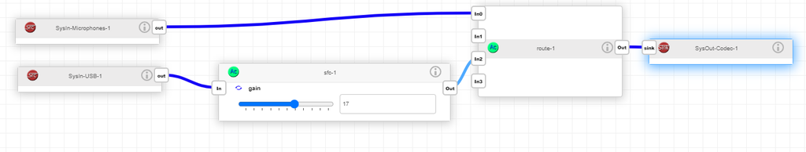

.

### Overview

This document provides a concise overview of an audio format conversion block designed to convert audio samples from one data type to another. The block supports various audio sample formats, including fixed-point 16-bit (fixed16), fixed-point 32-bit (fixed32), floating-point (float), and G.711 encoded data. It also supports PDM domain data and allows to convert the stream from MSB to LSB first. Additionally, it can handle the conversion of audio data between interleaved and non-interleaved formats.

The **sfc** is an essential tool for audio processing applications that require flexibility in handling different audio sample formats and interleaving options. By providing a straightforward interface for specifying the source and target formats, this block simplifies the process of audio data conversion for developers and audio engineers. It is widely used inside AudioChain and is also part of many algorithms so that they offer a wide range of input and output format capabilities. The downside may be that if the user doesn’t take good care, he may end up making a lot of useless conversions.

### Features

- **Multiple Format Support**:
  - **PCM domain**: Converts between fixed16, fixed32, float, and G.711 encoded formats.
  - **PDM domain**: Converts between MSB & LSB first.
- **Interleaving Conversion**: Transforms audio data between interleaved and non-interleaved formats.
- **Bit Depth Conversion**: Changes the bit depth of audio samples.
- **Gain Control**: Apply a gain given in dB.
- Note that it does not support:
  - **Sample Rate Conversion**, see the resample algorithm for that matter.
  - **Time to frequency domain conversion,** see the WOLA algorithm for that matter.

### Inputs/Outputs

- **Gain value**: Decibels
- **Audio Data**: The input audio samples to be converted. Multiple channels supported.
- **Source Format**: The current format of the input audio samples is known thanks to the input pin that is aware of its own properties including data type and interleaving as shown by next figure.
- **Target Format**: The desired format for the output audio samples is known thanks to the output pin that is aware of its own properties data type and interleaving as shown by next figure.

#### Output

- **Converted Audio Data**: The audio samples in the target format and interleaving option with chosen gain.

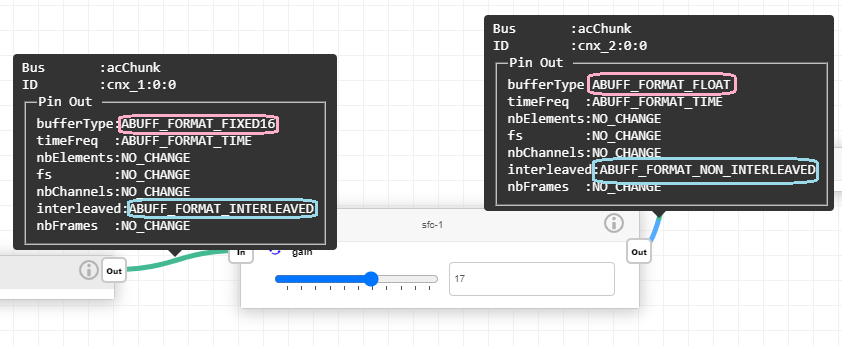

### Configuration Parameters

As shown in previous figure, there are two types of parameters:

- Format information is retrieved from the pins so that it is up to the user to configure the wires according to his desire.
- The gain is a more classical parameter which has a tuning box and a slider inside the sfc box to allow its setting.

## Sound-font

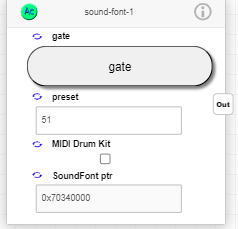

### Sound-font description.

A SoundFont (.sf2 file) is a type of audio file used for storing digital audio samples and associated instrument parameters. These files are designed to be used with MIDI synthesizers and software that support the SoundFont format. The SoundFont element allows playing an SF2 file flashed in the external memory, then plays keys using instrument presets. The Player is a generator and can be connected to any other element compatible with its chunk, such as a Faust reverb, viewer, etc.

**Notice**: This Element uses the external flash to load SF2 files.

The SF2 file needs to be packaged with a file signature and a file size. If the signature is missing, the element will not work and will report an issue in the log terminal. The SF2 packaging should be done using a bash script. When you execute the script Middlewares/ST/Audio-Kit/Tools/SoundFont.sh, you will be invited to select a board and an SF2 file. You must select an SF2 file compatible with the board’s performance.

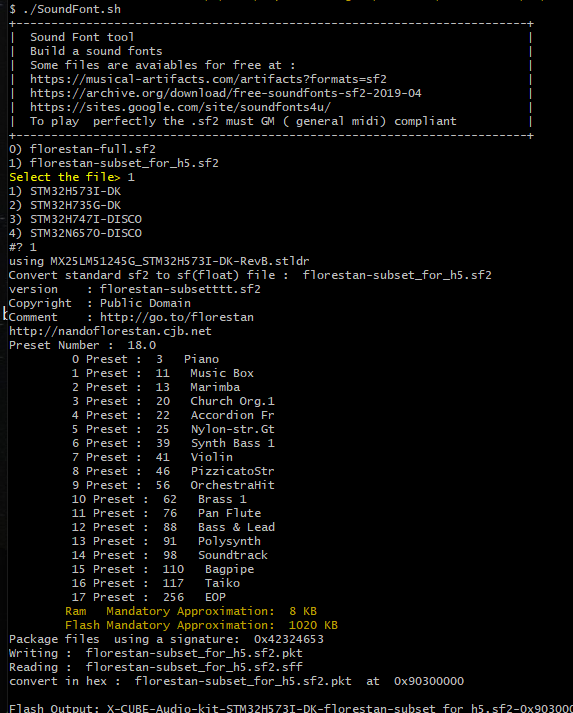

SoundFont.sh bash script.

The folder includes 2 free SF2 files coming from: https://musical-artifacts.com/artifacts?formats=sf2&tags=florestan

To be fully compliant with a standard MIDI file, the SF2 must be fully compliant with the General MIDI (GM) specifications.

- https://en.wikipedia.org/wiki/General_MIDI

The General MIDI specification details a set of presets along with an audio rendering specification.

The MIDI file could also be used for other use cases such as:

- Drum machine.
- Sample player.
- Events controller
- High-quality virtual keyboard.
- Etc.

This is why there are so many flavors of SF2 you can download from the web. The limitation is a compromise between SF2 memory space and sound rendering quality. An SF2’s size could vary from 200 Kilobytes to 500 Megabytes.

When you convert an SF2 using SoundFont.sh, the script will print the RAM and the flash memory required to run presets in yellow.

Here are some places where you can find free SF2 files for testing:

- https://musical-artifacts.com
- https://archive.org/download/free-soundfonts-sf2-2019-04
- https://sites.google.com/site/soundfonts4u

#### Using Sound-font in LiveTune

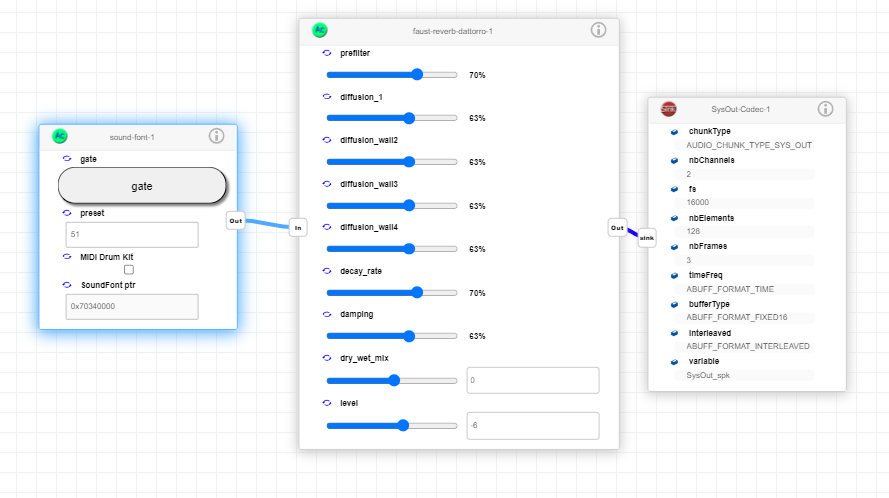

A Simple dataflow using Sound-Font

There are 4 controls:

[output not shown]

#### Performance consideration:

The MIDI format allows up to **16 channels** to be played simultaneously. A channel can play an instrument using several operators and processing, but the CPU load is not equivalent for all instruments. Some require multiple samples and more complex mathematics computed using double-precision floating points.

- The SoundFont is stored in the external flash. The external flash is not as fast as the internal flash and could exhibit significant latency depending on the MCU family and the flash chip mounted on the board. The CPU load displayed at the bottom of **LiveTune** can help you to check the CPU load consumed by the playback. The audio output frequency could also impact the performance mandatory for the playback.

For example, an **H5** has drastically less RAM than an **H7** and no external RAM. The H5 has a single-precision FPU, meaning that all mathematical operations using double precision will be computed by the CPU rather than the FPU. Furthermore, the H5’s CPU frequency is roughly half that of the H7. This implies that the H5 can be used for MIDI playback, but not for all use cases.

Example use cases:

- Example of Sound-Font files:
  - For the H5:
    - **florestan-subset_for_h5.sf2**: **number of presets reduced to fit the H5 ram memory.**
  - For other fast MCUs:
    - **florestan-full.sf2** or any others
- Example of midi-file
  - **midiFiles/venture.mid**

Consequently, to play a MIDI file properly, the MCU must meet the playback performance requirements.

#### Playing a Midi file

You have many options to play with your data flow. Basically, you need a MIDI device connected to the board USB:

Here are some possibilities:

- An application web example: https://signal.vercel.app/edit
  - **Warning**: Make sure the browser security policy allows Midi interfaces (chrome->setting->privacy->site setting->midi)

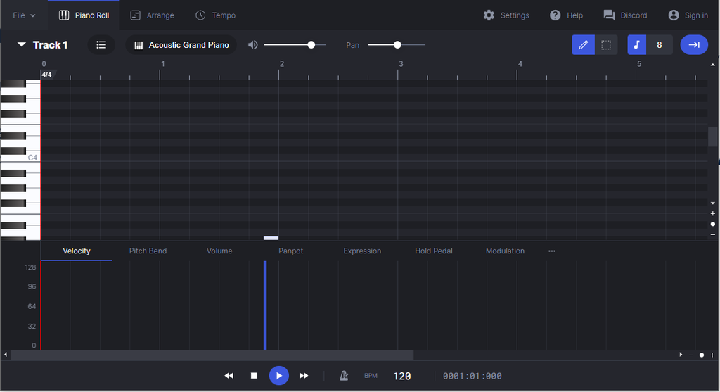

- Using a commercial or free PC tools such as the sequencer example : http://www.vanbasco.com for windows

[figure not shown]

- A physical Midi keyboards or physical Drum machine

[figure not shown]

All you need to do is to route MIDI output to the USB device “STM32 Midi”.

#### Midi device routing

To master the connection between midi device you need a **MIDI router**, it can be software or hardware. The device name could change, it can be called “**Midi host**” or “**Midi Controller**” by different manufacturers, but the role is equivalent. A MIDI router is a device or software that manages and directs MIDI data between MIDI-enabled devices. MIDI, which stands for Musical Instrument Digital Interface, is a technical standard that allows electronic musical instruments, computers, and other related devices to communicate and synchronize with each other. The Midi router could route Midi messages to an USB transport or the traditional Midi socket.

- Most of the PC Midi tools have a midi routing function to connect a Midi port “In” to a Midi port “Out”. Such as [MPC Beat](https://www.akaipro.com/mpc-beats) from AKAI
- Here is an example of HW Midi router device

[figure not shown]

- Alternatively, for a quick test, you can use a web midi router such as https://midi-router.tsoop.com allowing to connect a device to he Stm32board running Sound Font.

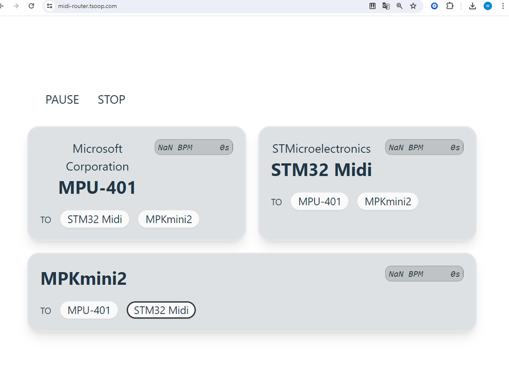

- To directly connect a MIDI device to another device, one of them must take the role of router (MIDI host). This case is not supported in Audio Kit. However, there are some reference projects on GitHub. https://github.com/rppicomidi/usb_midi_host implements this feature and using TinyUSB (the USB API used by Audio kit). This feature could be easily adapted to Audio Kit.

## Split

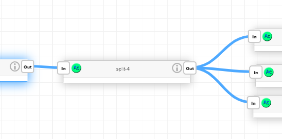

### Overview

This document describes an audio processing block designed to split a single input audio stream into multiple identical output streams. This splitter block is intended to distribute the same audio data to various processing units or signal paths, ensuring that each receives an exact copy of the input.

*Note: It is mandatory to use this block to distribute from a single output pin to several other input pins.*

### Features

- **Single Input Stream**: Accepts one audio input stream to be replicated.
- **Multiple Outputs**: Generates several output streams that are identical copies of the input.
- **Format Preservation**: Retains the original sample rate and the channel configuration.
- **Format Conversion**: Offers means to convert some characteristics of the signal: data type (fixed16, fixed32, float, etc…), interleaving.

### Inputs/Outputs

- **Input Streams**: The single audio input stream to be split.
- **Source Format**: The current format of the input audio samples is known thanks to the input pins that is aware of its own properties including data type and interleaving (see SFC documentation).
- **Target Format**: The desired format for the output audio samples is known thanks to the output pin that is aware of its own properties data type and interleaving (see SFC documentation).

#### Output

- **Replicated Audio Streams**: Multiple output streams that are replicas of the input stream. The replication is exact if **Target and Source formats** are equal.

### Processing Steps

Note: this algorithm encapsulates the SFC for input & output management. Please refer to its documentation.

- **Input Reception**: The block receives the input audio stream.
- **Signal Replication**:
  - The input stream is duplicated into multiple streams.
  - Each output stream is a replica of the input, with no alterations if **Target and Source formats** are equal. If **Target and Source formats** are different, the audio data remain the same but in a new shape (can be floating point from a fixed16 input stream or any other conversion that SFC can handle)
- **Output Distribution**:
  - The replicated streams are routed to their respective outputs.

### Configuration Parameters

The setting of the format conversion is handled by tuning the input & output pins according to the desired characteristics. Please refer to the SFC documentation.

## Stereo2Mono

Stereo to mono converter

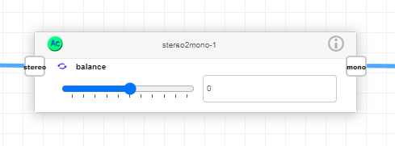

### Features

- **Input**: Accepts all PCM format, nbChannels must be equal to 2.
- **Output**: Accepts all PCM format, nbChannels must be equal to 1.
- **Format conversion**: Ability to change data format.

### Inputs/Outputs

- **Input Stream**: A single audio input stereo stream.
- **balance**: balance between left & right input channels, between -1 (only left), 0 (average of left & right channels) and +1 (only right)
  - left input channel gain = 0.5*(1-balance)
  - right input channel gain = 0.5*(1+balance)
- **Source Format**: The current format of the input audio samples is known thanks to the input pins that are aware of its own properties including data type and interleaving (see SFC documentation).
- **Target Format**: The desired format for the output audio samples is known thanks to the output pin that is aware of its own properties including data type and interleaving (see SFC documentation).

#### Output

- **Output Stream**: A single audio output mono stream.

### Processing Steps

1. **Input Handling**: input stream is received by the audio processing block.
2. **Gain control**:
   1. Left & right input channels gain application according to balance as explained above.

### Configuration Parameters

There are two types of parameters:

- Format information for conversion is retrieved from the pins so that it is up to the user to configure the wires according to his desire.
- The balance is a parameter which UI is provided as a tuning box and a slider.

## WOLA

Weighted OverLap and Add (forward and invert)

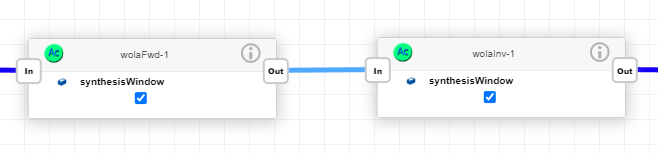

.

### Overview

Weighted Overlap-Add (WOLA) is a method for transforming audio signals between the time and frequency domains and vice versa. The WOLA method is an extension of the Overlap-Add (OLA) method, which is used to process long or streaming audio signals in chunks. WOLA incorporates a windowing function to reduce artifacts at the boundaries of the processed blocks, improving the quality of the reconstructed signal.

This algorithm is split in 2 algos wolaFwd & wolaInv:

- wolaFwd (WOLA forward) for conversion from time to frequency domain which uses the FFT (Fast Fourier Transform)
- wolaInv (WOLA inverse) for conversion from frequency to time domain which uses the IFFT (Inverse Fast Fourier Transform)
- they are always used together since system input/output signals are only time domain signals.

It is useful when building chain of algorithms that work in the frequency (or spectral) domain (such as fBeamforming algo, i.e. frequency beamforming or fnlms, i.e. subbands NLMS algorithm, etc…).

### Inputs/Outputs

Notes:

- In the time domain, the number of samples is retrieved from the input or output streams (acChunk buses) through the “nbElements” field.
- In the frequency domain, the number of bands is retrieved from the input or output streams (acChunk buses) through the “nbElements” field.
- **WolaFwd Input Stream**: mono or multichannel time domain data.
- **WolaInv Input Stream**: mono or multichannel frequency domain data.
- **Number of samples and number of bands**: the combination of these input/output streams properties permits to deduce the overlap ratio and the weighting window.

#### Output

- **WolaFwd Output Stream**: mono or multichannel frequency domain data.
- **WolaInv Output Stream**: mono or multichannel time domain data.

#### Frequency domain constraints in AudioChain/LiveTune

The constraints are the following ones:

1. **Format Constraint:**
   1. AudioChain frequency domain processing only supports non interleaved floating points data.
2. **WolaFwd** **input number of samples constraint:**
   1. WolaFwd consumes internally a power of 2 (i.e. …, 128, 256, 512, 1024, …) time domain samples for FFT reason and produces internally the same number of frequency domain samples.
   2. thus an overlap of successive input buffers (whose size may be any) is necessary.
   3. overlap ratio (deduced internally) permits to cope with this constraint.
3. **WolaFwd** **output number of bands constraint**:
   1. Internal frequency domain samples are complex and conjugate-symmetric, thus only half of the frequency domain samples are enough to keep the full spectral representation of time domain signal.
   2. However, there is the need for one more element for the DC component.
   3. Hence number of bands must be a power of 2 (half of FFT size) plus 1 elements (i.e. …, 65, 129, 257, 513, …).
4. **WolaFwd & WolaInv dependency constraints**:
   1. WolaFwd input buffer samples number and WolaInv output buffer samples number **must** be identical.
   2. WolaFwd output buffer bands number and WolaInv input buffer bands number **must** be identical.
5. **How overlap ratio and weighting windows are deduced internally**:
   1. The overlap ratio is deduced from the input & output number of elements (samples in time domain & bands in frequency domain)

      “overlap ratio”=1-“number of samples”/(2*(“number of bands”-1))
   2. a minimum overlap ratio of 25% is needed, thus some input vs output configurations wrt the number of samples/bands will be rejected if this overlap ratio constraint is not respected.

      1-“number of samples”/(2*(“number of bands”-1)) > 0.25

      “number of samples”/(2*(“number of bands”-1)) < 0.75

      “number of samples” < 0.75*(2*(“number of bands”-1))

      “number of samples” < 1.5*(“number of bands”-1)
   3. The window is then chosen to comply with [COLA constraint](https://www.dsprelated.com/freebooks/sasp/Dual_Constant_Overlap_Add.html), i.e. sum of ‘shifted by “number of samples”’ weighting windows is equal to 1.
   4. Overall weighting window may be split between analysis (WolaFwd) and synthesis (WolaInv): see synthesisWindow configuration parameter below

### Processing Steps

The WOLA processing block consists of the following stages:

- WolaFwd
  1. Windowing (analysis windowing).
  2. Block Processing: Organize the windowed signal into overlapping blocks.
  3. FFT: Compute the FFT of each block to obtain frequency-domain representation.
- WolaInv
  1. Inverse FFT (IFFT): Convert the processed blocks back to the time domain.
  2. Windowing (synthesis windowing), if synthesisWindow parameter enabled.
  3. Overlap-Add: Combine the overlapping time-domain blocks to reconstruct the signal.

### Configuration Parameters

wolaFwd and wolaInv configuration is done through:

1. **synthesisWindow**.

#### synthesisWindow

Mind that the same value (enabled or disabled) must be set for both WolaFwd & WolaInv.

If synthesisWindow is disabled, no windowing is applied by WolaInv. However the WolaFwd still applies its “analysis” windowing.

If synthesisWindow is enabled, the windowing is applied by both WolaFwd & WolaInv (in such case, the combination of “analysis window” and “synthesis window” is equal to synthesisWindow disabled’s “analysis window”)

If algorithms inserted in between wolaFwd and wolaInv are linear algorithms and don’t combine different signals, using synthesisWindow is useless. On the contrary, synthesisWindow is mandatory else the wolaInv will produce annoying audio artefacts (see https://www.dsprelated.com/freebooks/sasp/Weighted_Overlap_Add.html). As an example, fBeamforming and fnlms algorithms are doing linear processing but they combine different signals thus synthesisWindow must be enabled.

These analysis/synthesis windows and associated overlap ratio computed by WOLA algo insure optimal signal reconstruction for “time domain” → “frequency domain” → “time domain” transformation.

#### Overlap Ratio

As explained in the chapter called “Frequency domain constraints in AudioChain/LiveTune”, the overlap ratio is deduced from the input and output acChunks.

Following figure illustrates a case with an overlap ratio of 50%:

- The wolaFwd input is a time domain signal with 128 samples of 16 kHz (8 ms)
- The wolaFwd output is a frequency domain signal with 129 bands (first bin is for DC component). In this example, for simplicity, this is also the input of the WolaInv
- The wolaInv output is a time domain signal with 128 samples of 16 kHz (8 ms)
- Constraints explained in the chapter called “**Frequency domain constraints in AudioChain/LiveTune**” are respected,

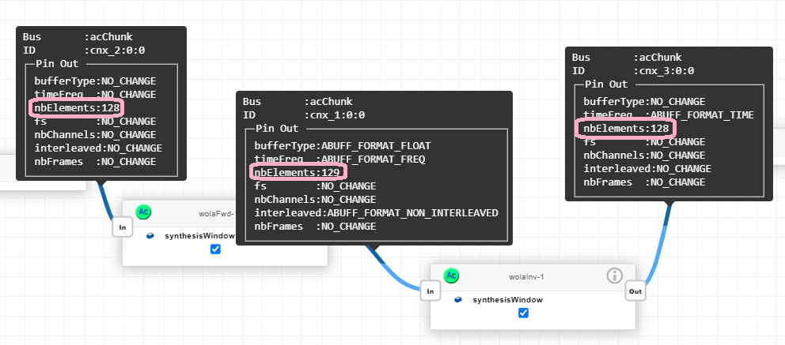

.

## Message Viewer

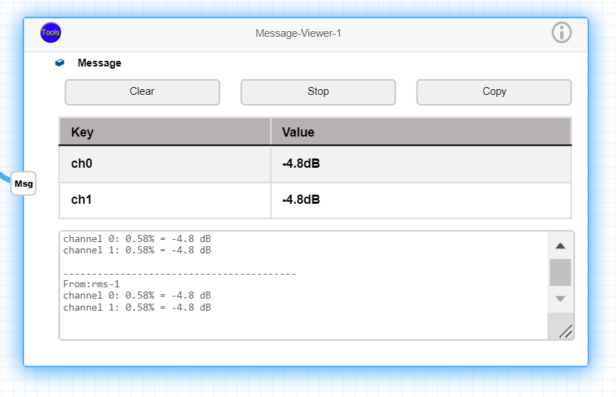

The message element is used for debugging purposes, it allows to display a text formatted by another element and sent it through pin **acMsg**. The message element has two displays, one for the text and one for the watch variables.

Panels will be visible only if data are sent to the element.

**Text Display:**

You can extract a snipped of text using the copy/past mechanism.

- The “Copy” button allows to copy the complete text buffer and variable snapshot in the clipboard.
- The “Stop/Continue” button allows to freeze the text scrolling.
- The “Clear” button allows to erase the text buffer.

**Implementation:**

The communication between the element and the message viewer is done using a Json string.

```
{
   "Signature": "acMsg",
   "Title": "Text",
   "From": "rms-1",
   "To": "Message-Viewer-1",
   "Vars": "ch0:-4.8dB ch1:-4.8dB",
   "Text": "channel 0: 0.58% = -4.8 dB\nchannel 1: 0.58% = -4.8 dB\n"
}
```

Json record

**Json fields:**

All other extra fields in the Json record will be ignored.

Vars and Text fields are optional.

- If the Vars field is not present in the record, the viewer won’t show it, same.
- If the Text field is not present in the record, the viewer won’t show it, same.

| Signature | Always acMsg |
| --- | --- |
| Title | Just an id used internally |
| From | Name instance of the element sender |
| To | Name instance of the element viewer |
| Vars | A string json Text encoded Key: Value separated by a space |
| Text | Any text as string json Text encoded |

Json fields

The element plugin_processing_rms.c is the perfect example implementing a both messages and variable transmissions.

Typically, a LiveTune plugin will use the **livetune_send_block_text_async** () function to send a payload to a “message viewer” element.

This low-level function sends a Json string using a signature. We can add optional some extra Json fields as a string and a text body.

So, we use this Prototype:

| pText message text as string | “hello world” |
| --- | --- |
| pExtra routing and variables as json | “From”:“rms-1”,“To”:“Message-Viewer-1”,“Vars”:“hello:world” |

```
/**
* @brief Send a json string to Livetune (asynchronous transmission)
* @param pSignature  type of message
* @param pTitle      title or id
* @param pExtra      title extra fields as text to concatenate to the json string, pExtra could be null
* @param pText       the text body in the field "Text:", pText could be null
*/

uint32_t livetune_send_block_text_async(uint8_t bForce, const char_t *pSignature, char_t *pTitle, char_t *pExtra, char_t *pText)
```

How to send a message to the element message view.

```
pExtra="From":"rms-1","To":"Message-Viewer-1","Vars":"ch0:-4.8dB ch1:-4.8dB";
pText= “Hello world”;
livetune_send_block_text_async(FALSE, "acMsg", "Text", pExtra, pText);
```